# Substitution of red meat with legumes and risk of primary liver cancer in 126,744 UK Biobank participants: a prospective cohort study

Niels Bock

2024-04-16

# Abstract

Objective:

Research Design and Methods:

Results:

Conclusions:

# Introduction

# Research Design and Methods

**Study population**

**Dietary assessment**

Researchers classified 79 food groups and 14 beverage groups from the Oxford WebQ food groups using UK National Diet and Nutrition Survey (NDNS) categories [3, 4]. We used this classification to categorise intake of foods groups to match our substitution analysis. Legume intake was defined as intake of dietary pulses, baked beans, tofu-based products, peas, hummus, soy drinks, and soy-based desserts and yoghurt; red meat intake was defined as intake of beef, pork, lamb, or other meat, including offal. Processed meat intake was defined as sausages, bacon (with and without fat), ham, or liver pate. Other food groups included were animal-based foods, unhealthy plant-based foods, healthy plant-based foods, and alcoholic beverages (supplemental table 1). animal-based and plant-based food groups were calculated in line with previous studies that used these food categories to construct a healthy plant-based diet index and an unhealthy plant-based diet index [5–8]. An overview of included foods in each food group is displayed in supplemental table 1.

**Liver cancer assessment**

Liver cancer was defined according to ICD-10 diagnosis codes C22.0 Hepatocellular carcinoma (HCC) or C22.1 Intrahepatic cholangiocarcinoma (ICC). Incident and prevalent cases of liver cancer and corresponding diagnosis dates were obtained via linkage to central cancer registers or hospital inpatient episodes [1].

**Assessment of confounders**

Confounders were defined *a priori* from a literature review of diet components as exposure and liver cancer as the outcome and illustrated using directed acyclic graphs (supplemental fig. 1.). The following confounding variables were selected: age (years [continuous]), sex (male, female [categorical]), educational level (high: College or University degree, intermediate: A levels/AS levels, O levels/GCSEs, or equivalent, low: none of the previous mentioned [categorical]), Townsend Deprivation Index [continuous], Living alone (yes, no [categorical]), waist circumference (cm [continuous]), physical activity (above/below the 2017 UK Physical activity guidelines of 150 minutes of moderate activity per week or 75 minutes of vigorous activity, or missing data [categorical]), smoking (pack years as a proportion of lifespan exposed to smoking [continous]), and alcohol intake (grams/day continuous). All confounders except age were selected from the initial assessment visit before the start of follow-up.

**The substitution model**

Substitutions were carried out in an equal-mass manner, i.e., substituting x grams of red meats with x grams of legumes. The size of the substitution was set to 15 grams of legumes for 15 grams of red meats to keep the substitution size below the mean intake any of the substituted food groups in the cohort. Substitutions were modelled using the leave-one-out-approach in which variables for every food group along with a variable for total food intake are included, except the food group that are to be substituted [9]. To estimate substitution of 15 grams of all red meats with 15 grams of legumes, the following model was defined:

$$log(h(t;x)) = log(h(0;t)) + \beta_1 Legumes (15g) + \beta_2 Total food intake (g) + \beta_3 Other food groups(g) + \beta_4 Covariates$$

When substituting red meat with legumes, processed meat was added to the model:

$$log(h(t;x)) = log(h(0;t)) + \beta_1 Legumes (15g) + \beta_2 Processed meat (15g) + \beta_3 Total food intake (g) + \beta_4 Other food groups(g) + \beta_5 Covariates$$

When substituting processed meat with legumes, red meat was added to the model:

$$log(h(t;x)) = log(h(0;t)) + \beta_1 Legumes (15g) + \beta_2 Red meat (15g) + \beta_3 Total food intake (g) + \beta_4 Other food groups(g) + \beta_5 Covariates$$

**Statistical analysis**

Multivariable-adjusted Cox proportional hazards regression models were used to estimate hazard ratios (HR) with corresponding 95% confidence intervals (CI) with age as the underlying timescale. Participants were followed from the date of their last completed diet questionnaire until the event of interest occurred or due to right censoring, whichever came first. Participants were right censored due to one of the following events occurring: death, loss to follow-up, or administrative end of follow-up (set to Jan 31, 2022). Two levels of adjustments were added to the substitution model. A crude model was minimally adjusted for age, total weight of food intake, and all other foods groups to fit the substitution model. The adjusted model was further adjusted for sex, educational level, Townsend Deprivation Index, living alone, physical activity, smoking, alcohol intake, and waist circumference.

A stratified analysis on each cancer type was performed to test whether pooling of HCC and ICC as an outcome was justified. Further, the following sensitivity analyses were performed to test the robustness of the main analysis:

To estimate the effect of legume intake regardless of other dietary components, legume consumers (divided into quartiles) were compared to non-consumers.

All analyses were conducted in R with a significance level of 5 %.

# Results

After excluding participants with liver cancer and participants lost to follow-up before baseline, 126,744 participants remained who had completed two or more diet questionnaires. During a median follow-up time of 11.3 years, 173 participants developed liver cancer. Baseline characteristics are displayed in table 1. Participants who developed liver cancer were older at baseline, had a higher waist circumference, were less physically active, fewer had never smoked, and more were male, compared to all included participants.

Mean daily energy intake and food intake and median daily intake of all specified food groups are presented in table 2.

Main results are presented in table 3. In the crude model, no association was found for substituting 15 grams of legumes per day with 15 grams of total meat, red meat, or processed meat per day and risk of primary liver cancer (total meat: HR: 0.98 (95% CI: 0.93, 1.04), red meat: HR: 0.97 (95% CI: 0.91-1.03) and processed meat: HR 1.02 (95% CI:0.93, 1.13)). the results did not change when with further adjustments (total meat: HR: 1.02 (95% CI: 0.96, 1.08), red meat: HR: 1.00 (95% CI: 0.94-1.07) and processed meat: HR: 1.09 (95% CI: 0.98, 1.20).

Estimates seemed to go in opposite directions when substituting total meat or red meat with legumes for risk of HCC (total meat: HR: 1.08 (95% CI: 0.99, 1.19), red meat: HR: 1,07 (95% CI: 0.97, 1.18) and processed meat: HR: 1.12 (95% CI: 0.97, 1.30)) and ICC (total meat: HR: 0.97 (95% CI: 0.90, 1.05), red meat: HR: 0.95 (95% CI: 0.87, 1.03) and processed meat: HR: 1.06 (95% CI: 0.92, 1.22)) , but these trends were not statistically significant (supplementary table 2). Further, excluding high alcohol consumers or food intake misreporters or setting inclusion criteria to ≥ 3 completed diet questionnaires did not alter the estimates in any statistically significant way (supplementary tables 3 to 5). In the adjusted no substitution analysis, a mean intake of 6.3 grams of legumes per day was associated with a reduced risk of liver cancer, compared to no intake (HR: 0.59 (95% CI: 0.35, 0.98)); however, no associations were observed with further increase in legume intake (supplementary table 6).

# Conclusions

# Acknowledgements

# References

1.

Sudlow C, Gallacher J, Allen N, et al (2015) UK Biobank: An Open Access Resource for Identifying the Causes of a Wide Range of Complex Diseases of Middle and Old Age. PLOS Medicine 12(3):e1001779. https://doi.org/10.1371/journal.pmed.1001779

2.

Piernas C, Perez-Cornago A, Gao M, et al (2021) Describing a new food group classification system for UK biobank: analysis of food groups and sources of macro- and micronutrients in 208,200 participants. European Journal of Nutrition 60(5):2879–2890. https://doi.org/10.1007/s00394-021-02535-x

3.

Liu B, Young H, Crowe FL, et al (2011) Development and evaluation of the Oxford WebQ, a low-cost, web-based method for assessment of previous 24 h dietary intakes in large-scale prospective studies. Public Health Nutrition 14(11):1998–2005. https://doi.org/10.1017/s1368980011000942

4.

Greenwood DC, Hardie LJ, Frost GS, et al (2019) Validation of the Oxford WebQ Online 24-Hour Dietary Questionnaire Using Biomarkers. American Journal of Epidemiology 188(10):1858–1867. https://doi.org/10.1093/aje/kwz165

5.

Thompson AS, Tresserra-Rimbau A, Karavasiloglou N, et al (2023) Association of Healthful Plant-based Diet Adherence With Risk of Mortality and Major Chronic Diseases Among Adults in the UK. JAMA Network Open 6(3):e234714. https://doi.org/10.1001/jamanetworkopen.2023.4714

6.

Heianza Y, Zhou T, Sun D, Hu FB, Qi L (2021) Healthful plant-based dietary patterns, genetic risk of obesity, and cardiovascular risk in the UK biobank study. Clinical Nutrition 40(7):4694–4701. https://doi.org/10.1016/j.clnu.2021.06.018

7.

Satija A, Bhupathiraju SN, Spiegelman D, et al (2017) Healthful and Unhealthful Plant-Based Diets and the Risk of Coronary Heart Disease in U.S. Adults. Journal of the American College of Cardiology 70(4):411–422. https://doi.org/10.1016/j.jacc.2017.05.047

8.

Satija A, Bhupathiraju SN, Rimm EB, et al (2016) Plant-Based Dietary Patterns and Incidence of Type 2 Diabetes in US Men and Women: Results from Three Prospective Cohort Studies. PLOS Medicine 13(6):e1002039. https://doi.org/10.1371/journal.pmed.1002039

9.

Ibsen DB, Laursen ASD, Würtz AML, et al (2021) Food substitution models for nutritional epidemiology. The American Journal of Clinical Nutrition 113(2):294–303. https://doi.org/10.1093/ajcn/nqaa315

# Tables

**Table 1. Baseline characteristics of UK Biobank participants who completed ≥ 2 Oxford WebQ 24-hour diet recall.**

| **Variable** | **All participants** **N = 126,744**<sup>1</sup> | **Participants who developed liver cancer** **N = 173**<sup>1</sup> |
| --- | --- | --- |
| Typical diet yesterday<sup>2</sup> | 73,213 (58%) | 105 (61%) |
| Age | 60 (53, 65) | 64.0 (60.0, 68.0) |
| Sex |  |  |
| Female | 70,659 (56%) | 65 (38%) |
| Male | 56,085 (44%) | 108 (62%) |
| Educational level |  |  |
| High | 59,416 (47%) | 76 (44%) |
| Intermediate | 41,817 (33%) | 52 (30%) |
| Low | 25,472 (20%) | 45 (26%) |
| Missing | 39 |  |
| Townsend Deprivation Index | -2.4 (-3.8, 0.0) | -2.6 (-3.7, -0.7) |
| Missing | 149 |  |
| Living alone | 22,658 (18%) | 34 (20%) |
| Missing | 171 |  |
| Physical activity<sup>3</sup> |  |  |
| Above | 58,111 (46%) | 61 (35%) |
| Below | 50,712 (40%) | 79 (46%) |
| Missing | 17,921 (14%) | 33 (19%) |
| Smoking |  |  |
| Never | 72,583 (57%) | 75 (43%) |
| Ever | 54,122 (43%) | 98 (57%) |
| Missing | 39 |  |
| Alcohol intake [g/day] | 11 (0, 26) | 11 (0, 29) |
| Waist circumference [cm] | 88 (79, 97) | 98 (89, 107) |
| Missing | 168 |  |

<sup>1</sup> n (%); Median (IQR)  
<sup>2</sup> Participants who reported eating a typical diet yesterday for all completed diet questionnaires.  
<sup>3</sup> Above or below the 2017 UK Physical activity guidelines of 150 minutes of moderate activity per week or 75 minutes of vigorous activity.

**Table 2. Daily dietary intake.**

| **Daily food intake** | **Cohort** **N = 126,744**<sup>1</sup> | **Liver cancer** **N = 173**<sup>1</sup> |
| --- | --- | --- |
| Total food intake [kJ/day] or [g/day] |  |  |
| Energy [kJ] | 8,643 (2,171) | 8,903 (2,281) |
| Weight [g] | 3,210 (715) | 3,221 (714) |
| Food groups [g/day] |  |  |
| Legumes | 11 (0, 34) | 8 (0, 35) |
| Red and processed meat | 53 (15, 86) | 60 (30, 95) |
| Red meat | 30 (0, 60) | 45 (0, 73) |
| Processed meat | 9 (0, 30) | 8 (0, 31) |
| Other animal-based foods | 475 (361, 603) | 448 (322, 604) |
| Healthy plant-based foods | 1,806 (1,454, 2,198) | 1,791 (1,365, 2,158) |
| Unhealthy plant-based foods | 472 (324, 662) | 491 (365, 698) |
| Alcoholic beverages | 132 (0, 342) | 144 (0, 375) |

<sup>1</sup> mean (±SD) for total energy and food intake; median (IQR) for food groups

**Table 3. Hazard ratios for substitution of legumes for total meat, red meat and processed meat.** (N = 126744)

| **15 g/day substitution** | Crude<sup>1</sup> **HR** | Crude<sup>1</sup> **95% CI** | Crude<sup>1</sup> **p-value** | Adjusted<sup>2</sup> **HR** | Adjusted<sup>2</sup> **95% CI** | Adjusted<sup>2</sup> **p-value** |
| --- | --- | --- | --- | --- | --- | --- |
| Legumes for total meat | 0.98 | 0.93, 1.04 | 0.5 | 1.02 | 0.96, 1.08 | 0.5 |
| Legumes for red meat | 0.97 | 0.91, 1.03 | 0.3 | 1.00 | 0.94, 1.07 | >0.9 |
| Legumes for processed meat | 1.02 | 0.93, 1.13 | 0.6 | 1.09 | 0.98, 1.20 | 0.11 |

<sup>1</sup> Adjusted for age (as underlying timescale), other food groups and total food intake to fit the substitution model.  
<sup>2</sup> Further adjusted for sex, educational level, Townsend Deprivation Index, living alone, physical activity, smoking, alcohol intake and waist circumference.

# Figures

# Supplemental Material

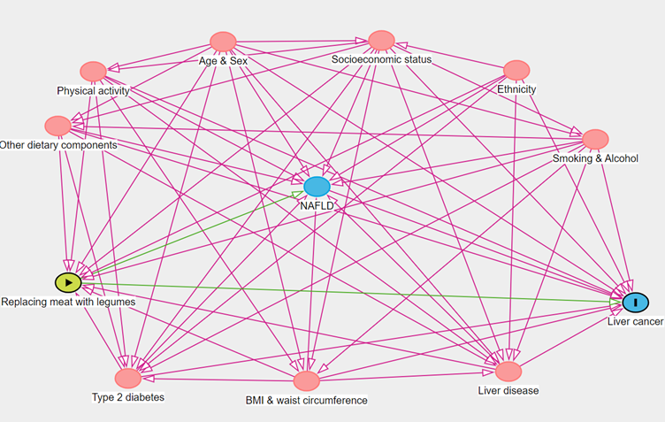

Figure 1. Directed acyclic graph visualizing the relationship between the exposure, replacing meat with legumes, and the outcome, liver cancer. Red circles indicate ancestors of exposure and outcome with red arrows being biasing paths. The NAFLD circle is blue to indicate that it is an ancestor of the outcome. The green arrows are causal paths.

**Supplementary table 1. Summary of included foods for each food group.**

| **Food group** | **Includes** | **UK Biobank ID** |
| --- | --- | --- |
| Legumes |  |  |
| Soya-based desserts & yogurt | Soya-based desserts | p26086 |
| Legumes/pulses | Baked beans, pulses | p26101 |
| Soy drink | Soya drinks (including calcium fortified) | p26136 |
| Soy-based meals | Tofu-based products | p26137 |
| Vegetable dips | Hummus, guacamole (assuming 50% hummus) | p26144 |
| Peas/sweetcorn | Peas, sweetcorn (assuming 50% peas) | p26115 |
| Red meat |  |  |
| Beef | Beef | p26066 |
| Lamb | Lamb | p26100 |
| Other meat, offal | Other meat including offal | p26104 |
| Pork | Pork | p26117 |
| Processed meat |  |  |
| Processed meat | Sausages, bacon (with and without fat), ham, liver pate | p26122 |
| Animal-based foods |  |  |
| Poultry |  |  |
| Breaded/battered Chicken | Fried poultry with batter/breadcrumbs | p26069 |
| Poultry | Poultry (with/without skin) | p26121 |
| Fish |  |  |
| Bre aded/battered Fish | Fried fish with batter/breadcrumbs | p26070 |
| Oily fish | Oily fish, including salmon | p26109 |
| Shellfish | Prawns, lobster, crab, shellfish | p26132 |
| White fish & tinned tuna | Tinned tuna, white fish, other fish | p26149 |
| Dairy |  |  |
| Dairy fat spread lower fat | Spreadable/lower fat butter, dairy-based very low fat spread | p26062 |
| Dairy fat spread | Spreadable normal fat butter, dairy-based normal fat spread (including cholesterol lowering spread) | p26063 |
| Milk-dairy desserts | Ice cream, milk puddings, milk-based desserts, cheesecake | p26084 |
| Milk-based & powdered drinks | Dairy-based smoothies, milk-based drinks, hot chocolate | p26087 |
| Full fat yogurt | Whole milk yogurt (plain) | p26096 |
| High fat cheese | Cheese >17.5 g fat per 100 g, including hard cheese, soft cheese, spreadable, Blue, Feta, Mozzarella, Goats, other) | p26099 |

[output cut: 90 more lines]

**Supplementary table 2. Hazard ratios for substitution of legumes for total meat, red meat and processed meat for hepatocellular carcinoma (Hcc) and intrahepatic cholangiocarcinoma (ICC).** (N = 126744)

| **15 g/day substitution** | Crude<sup>1</sup> **HR** | Crude<sup>1</sup> **95% CI** | Crude<sup>1</sup> **p-value** | Adjusted<sup>2</sup> **HR** | Adjusted<sup>2</sup> **95% CI** | Adjusted<sup>2</sup> **p-value** |
| --- | --- | --- | --- | --- | --- | --- |
| Hepatocellular carcinoma |  |  |  |  |  |  |
| Legumes for total meat | 1.03 | 0.94, 1.12 | 0.5 | 1.08 | 0.99, 1.19 | 0.087 |
| Legumes for red meat | 1.03 | 0.93, 1.13 | 0.6 | 1.07 | 0.97, 1.18 | 0.2 |
| Legumes for processed meat | 1.03 | 0.89, 1.19 | 0.7 | 1.12 | 0.97, 1.30 | 0.13 |
| Intrahepatic cholangiocarcinoma |  |  |  |  |  |  |
| Legumes for total meat | 0.95 | 0.87, 1.02 | 0.2 | 0.97 | 0.90, 1.05 | 0.5 |
| Legumes for red meat | 0.93 | 0.85, 1.01 | 0.068 | 0.95 | 0.87, 1.03 | 0.2 |
| Legumes for processed meat | 1.02 | 0.89, 1.17 | 0.8 | 1.06 | 0.92, 1.22 | 0.4 |

<sup>1</sup> Adjusted for age (as underlying timescale), other food groups and total food intake to fit the substitution model.  
<sup>2</sup> Further adjusted for sex, educational level, Townsend Deprivation Index, living alone, physical activity, smoking, alcohol intake and waist circumference.

**Supplementary table 3. Exclusion of high alcohol consumers. Hazard ratios for substitution of legumes for total meat, red meat and processed meat.** (N = 97276)

| **15 g/day substitution** | Crude<sup>1</sup> **HR** | Crude<sup>1</sup> **95% CI** | Crude<sup>1</sup> **p-value** | Adjusted<sup>2</sup> **HR** | Adjusted<sup>2</sup> **95% CI** | Adjusted<sup>2</sup> **p-value** |
| --- | --- | --- | --- | --- | --- | --- |
| Legumes for total meat | 0.97 | 0.91, 1.04 | 0.4 | 1.00 | 0.94, 1.07 | >0.9 |
| Legumes for red meat | 0.97 | 0.90, 1.04 | 0.3 | 0.99 | 0.92, 1.06 | 0.8 |
| Legumes for processed meat | 0.99 | 0.89, 1.11 | 0.9 | 1.04 | 0.93, 1.17 | 0.5 |

<sup>1</sup> Adjusted for age (as underlying timescale), other food groups and total food intake to fit the substitution model.  
<sup>2</sup> Further adjusted for sex, educational level, Townsend Deprivation Index, living alone, physical activity, smoking, alcohol intake and waist circumference.

**Supplementary table 4. Exclusion of food intake misreporters. Hazard ratios for substitution of legumes for total meat, red meat and processed meat.** (N = 125914)

| **15 g/day substitution** | Crude<sup>1</sup> **HR** | Crude<sup>1</sup> **95% CI** | Crude<sup>1</sup> **p-value** | Adjusted<sup>2</sup> **HR** | Adjusted<sup>2</sup> **95% CI** | Adjusted<sup>2</sup> **p-value** |
| --- | --- | --- | --- | --- | --- | --- |
| Legumes for total meat | 0.98 | 0.92, 1.04 | 0.5 | 1.02 | 0.96, 1.08 | 0.6 |
| Legumes for red meat | 0.97 | 0.91, 1.03 | 0.3 | 1.00 | 0.94, 1.06 | >0.9 |
| Legumes for processed meat | 1.02 | 0.93, 1.13 | 0.7 | 1.09 | 0.98, 1.20 | 0.11 |

<sup>1</sup> Adjusted for age (as underlying timescale), other food groups and total food intake to fit the substitution model.  
<sup>2</sup> Further adjusted for sex, educational level, Townsend Deprivation Index, living alone, physical activity, smoking, alcohol intake and waist circumference.

**Supplementary table 5. Participant who completed three or more diet questionnaires. Hazard ratios for substitution of legumes for total meat, red meat and processed meat.** (N = 78660)

| **15 g/day substitution** | Crude<sup>1</sup> **HR** | Crude<sup>1</sup> **95% CI** | Crude<sup>1</sup> **p-value** | Adjusted<sup>2</sup> **HR** | Adjusted<sup>2</sup> **95% CI** | Adjusted<sup>2</sup> **p-value** |
| --- | --- | --- | --- | --- | --- | --- |
| Legumes for total meat | 1.00 | 0.93, 1.07 | >0.9 | 1.04 | 0.97, 1.12 | 0.3 |
| Legumes for red meat | 0.98 | 0.91, 1.07 | 0.7 | 1.02 | 0.94, 1.11 | 0.7 |
| Legumes for processed meat | 1.04 | 0.91, 1.19 | 0.5 | 1.11 | 0.97, 1.27 | 0.12 |

<sup>1</sup> Adjusted for age (as underlying timescale), other food groups and total food intake to fit the substitution model.  
<sup>2</sup> Further adjusted for sex, educational level, Townsend Deprivation Index, living alone, physical activity, smoking, alcohol intake and waist circumference.

**Supplementary table 6. No intake of legumes vs. quartiles of daily legume intake** (N = 126744)

| **Characteristic** | Crude<sup>1</sup> **HR** | Crude<sup>1</sup> **95% CI** | Crude<sup>1</sup> **p-value** | Adjusted<sup>2</sup> **HR** | Adjusted<sup>2</sup> **95% CI** | Adjusted<sup>2</sup> **p-value** |
| --- | --- | --- | --- | --- | --- | --- |
| Legume category<sup>3</sup> |  |  |  |  |  |  |
| No intake | — | — |  | — | — |  |
| Q1 | 0.58 | 0.35, 0.96 | 0.034 | 0.59 | 0.35, 0.98 | 0.042 |
| Q2 | 0.84 | 0.54, 1.29 | 0.4 | 0.85 | 0.55, 1.32 | 0.5 |
| Q3 | 0.75 | 0.47, 1.19 | 0.2 | 0.75 | 0.47, 1.20 | 0.2 |
| Q4 | 1.02 | 0.66, 1.56 | >0.9 | 1.10 | 0.71, 1.69 | 0.7 |

<sup>1</sup> Adjusted for age (as underlying timescale), other food groups and total food intake to fit the substitution model.  
<sup>2</sup> Further adjusted for sex, educational level, Townsend Deprivation Index, living alone, physical activity, smoking, alcohol intake and waist circumference.  
<sup>3</sup> mean daily intake of legumes in grams for each quartile: Q1: 6.3, Q2: 15.7, Q3: 34.3, Q4 109.